# SynGen: overview

by Nick Giangreco

# What is SynGen

**Syngen is a new algorithm developed in the Califano lab for inferring synergistic interactions between treatments (drugs). SynGen works in two parts. Computing a relationship between a drug and patient signature and then estimates synergy between two drug signatures found to significantly treat the patient signature found in the former step.**

**In a given patient, the regulator activities are ranked from highest to lowest estimated activity. In a given drug signature, the genes are matched in the ranked signature from the patient. Then there’s bifurcation. First, the tumor signature (as derived above using the viper scores in the patient) is compared to the drug signature (as derived from above using the viper scores in the perturbed cell line). The distance is calculated between the two signatures, where larger distance means the regulator activities after drug perturbation are opposite, or close to opposite, to regulators in the tumor signature and vice versa. Second, the drug synergy is estimated. The procedure is actually calculating how much the drugs complement each other-if drug A produces a perturbation exactly like drug B then there’s no synergy by definition. If drug A produces a similar perturbation as drug B so as to have similar activity but in different targets, then there’s said to be synergy. If there’s synergy, by definition the perturbations by the two drugs have a better reversal of the tumor signature and thus might have a better treatment affect.**

**This Rmarkdown document will go through the main function of SynGen, including the original code, called *phenoDrug* to give a transparent view of the inference method and understand each section of the function.**

# Load your data

**I’m loading data that I’m using for the GBM project. Then I’m also loading the functions directly so I can go through the code sequentially. (Note: you may have to change the paths so that you can run this document on your machine).**

```r
load("Z:/npg2108/RDAs/syngen.RDa")
#load("/Volumes/ac_lab_scratch/npg2108/RDAs/syngen.RDa")
path="I:/npg2108/syngen-svn-2/syngen-svn-2_mod/R/"
#path="/Volumes/ac_lab/npg2108/syngen-svn-2/syngen-svn-2_mod/R/"
source(paste0(path,"internal.R"))
source(paste0(path,"syngen.R"))
```

**The tumor viper matrix contains the inferred protein activity (VIPER) scores for the 41 patients with GBM across the 5923 regulators.**

```r
dim(vprgbm_rpkm)
```

```
## [1] 5923   41
```

**The drug viper matrix contains the the inferred protein activity (VIPER) scores for the 277 drug perturbations across 2447 regulators in the u87 cell line.**

```r
dim(sub_vpmat)
```

```
## [1] 2447  277
```

**Pre-processing: first I need to make sure the genes match in both matrices before giving to syngen.**

```r
dim(dr)
```

```
## [1] 2435  277
```

```r
dim(ds)
```

```
## [1] 2435   41
```

# Syngen function: phenoDrug

**phenoDrug is the main function call for SynGen. The function predicts single agent and 2-way combinations that may induce reversal of the tumor signature.**

**The first two arguments are the phenotype viper vector or matrix (ds) and then the drug viper matrix (dr). In our case, since we want to do our predictions for a single patient, we will only give a single column of the matrix as an example. In practice, if our goal is to predict for all patients individually, I would execute a loop or better yet some kind of parallelization.**

```r
phsig<-ds[,"GBM61"]
drugsig<-dr
```

**We will indicate the method to use (there’s three to choose from) to be ‘complemental’ to estimate synergy. This method is preferred because we can think of synergy as complementation-two entities working together to induce a larger effect than just adding two individual effects together.**

```r
method<-"complemental"
```

**We will initialize the other parameters to their default settings indicated in help(“phenoDrug”).**

```r
nn<-NULL
ws=2
similarity<-"two.sided"
cutoff<-0.01
scc<-NULL
phdistance<-TRUE
score<-1
ints<-0
symetric<-TRUE
```

**The function is computed in the following sections:**

**1. Initializating**

**2. Compatibilizing the phenotype signature and drug signature**

**3. Computing phenotype / drug association**

**4 and 5. Selecting the significant compounds and estimating expected p-value for additive effect**

**6. Similarity between drugs**

**7. Defining all drug combinations**

**8. Computing the synergy score**

## 1. Initializing

This step corrects formatting and variable initialization such as:

- Providing a score if none is given.
- Converting the phenotype object into a matrix if only a vector is given (as in our case).
- Setting the number of genes to use for the reciprical enrichment analysis (when determining if regulator activities are juxtaposed between signatures) to 10% of the number of shared genes between the matrices (default).
- Putting the drug viper matrix into a list as the first and only element of that list.

```r
    if (length(score)==1) score <- rep(score, 2)
    if (is.null(ncol(phsig))) {
        phsig <- matrix(phsig, length(phsig), 2, dimnames=list(names(phsig), NULL))
    }
    if (is.null(nn) & ws==0) {
        nn <- round(length(which(rownames(phsig) %in% rownames(drugsig)))/10)
    }
    ds <- phsig
    if (!is.list(drugsig)) drugsig <- list(drugsig)
```

## 2. Compatibilizing the drug matrix with the phenotype signature

In this step, all the drug names in the drug viper matrix are made sure to be unique (not occuring in more than one column) and the gene names are confirmed to be shared and having the same position in both matrices (excluding duplicates). Unfortunately, this step only checks shared genes in the drug matrix, not the phenotype matrix. Downstream, this fabricates data when computing similarity between the signatures, so it’s imperative to do this pre-processing prior to inputting the matrices into phenoDrug. The code should be modified.

```r
    drugs <- unique(unlist(lapply(drugsig, colnames), use.names=F))
    genes <- table(unlist(lapply(drugsig, rownames), use.names=F))
    genes <- names(genes)[genes==length(drugsig) & names(genes) %in% rownames(phsig)]
    drugsig <- lapply(drugsig, function(x, drugs, genes) {
        x[match(genes, rownames(x)), ][, match(drugs, colnames(x))]
    }, drugs=drugs, genes=genes)
```

## 3. Computing phenotype / drug association

Preceding this step are all the necessary pre-processing such as initializing parameters, formatting data objects, and adjusting the phenotype and drug matrices for sharing genes with having the same position as well. In this step, now we are comparing the phenotype and drug signature, where this is done with the *viperSimilarity* function. Essentially, *viperSimilarity* is analogous to the rotation matrix for PCA in that the features are reduced. But instead of capturing the maximum variance, the reduction method measures the similarity of the signatures and assigns a score. In the implementation it estimates the similarity of the inverse signature-biologically we want to know if the drug signature (regulator activities) is a reversal of the tumor signature. Thus, if the inverse of the signature is very similar, the drug is likely to “treat” the phenotype. But before estimation, the phenotype and viper signatures have to be standardized so that they can be compared. For example, if we plot the distribution of the phenotype distribution,

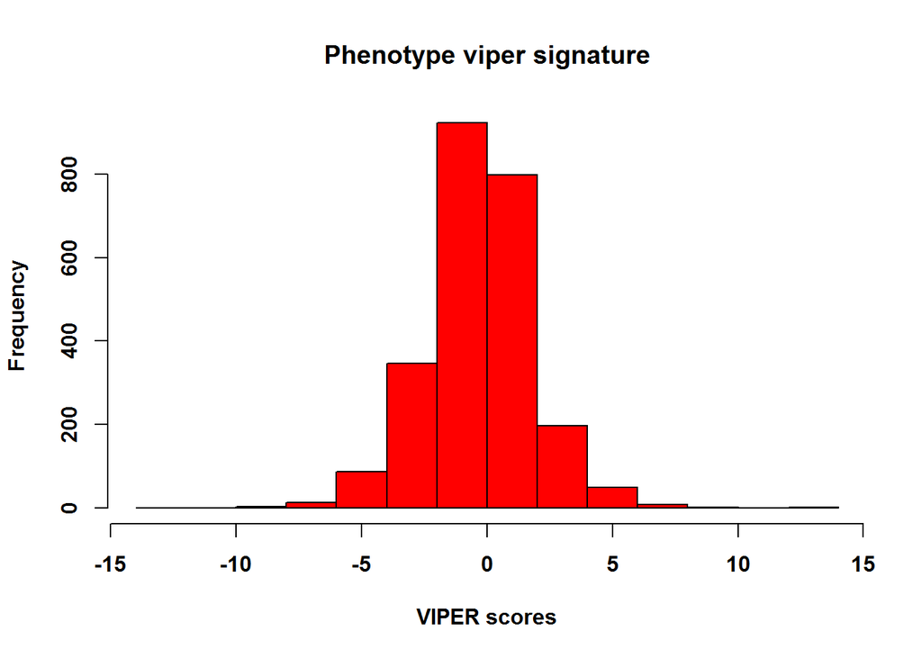

and then the distribution for a drug,

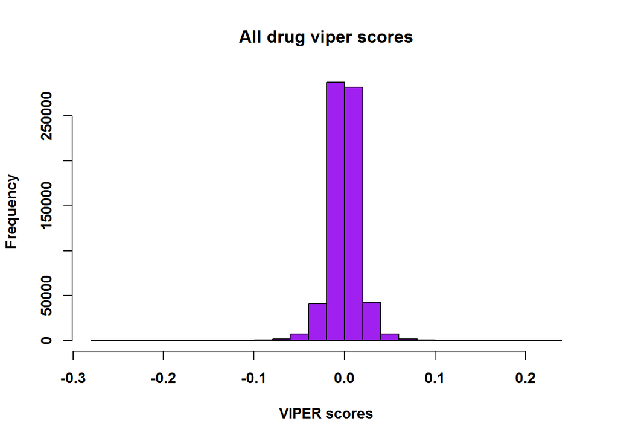

By viewing the viper scores on the x-axis, you can see that the distributions have very different ranges. *viperSimilarity* isn’t concerned with the difference in range for estimating the signature similarity, but only the ranking of regulator activity in the signatures. Thus, standardization of the two signatures is done, so each signature will then lie between -1 and 1 (the overall shape is the same but the range is standardized so comparisons of the rankings can be made). After standardization, the distributions are then z transformed and with many other transformations we get an estimate for how the drug signatures relate to the signature of the phenotype.

```r
    if (phdistance) {
        tmp <- sapply(drugsig, function(x, phsig, similarity, nn, ws) {
            scale(viperSimilarity(cbind(phsig, -x), nn=nn, method=similarity, ws=ws, symetric=symetric))[, -1][1, ]
        }, phsig=phsig[, 1], nn=nn, similarity=similarity, ws=ws)
        ds <- rowMeans(cortest(tmp, length(genes), alternative="greater")$z)
    }
    if (is.null(nrow(ds))) {
        ds <- matrix(ds, length(ds), 2, dimnames=list(names(ds), NULL))
    }
    dnes <- ds
    ds1 <- max(abs(ds))
    ds <- pnorm(ds, lower.tail=F)
```

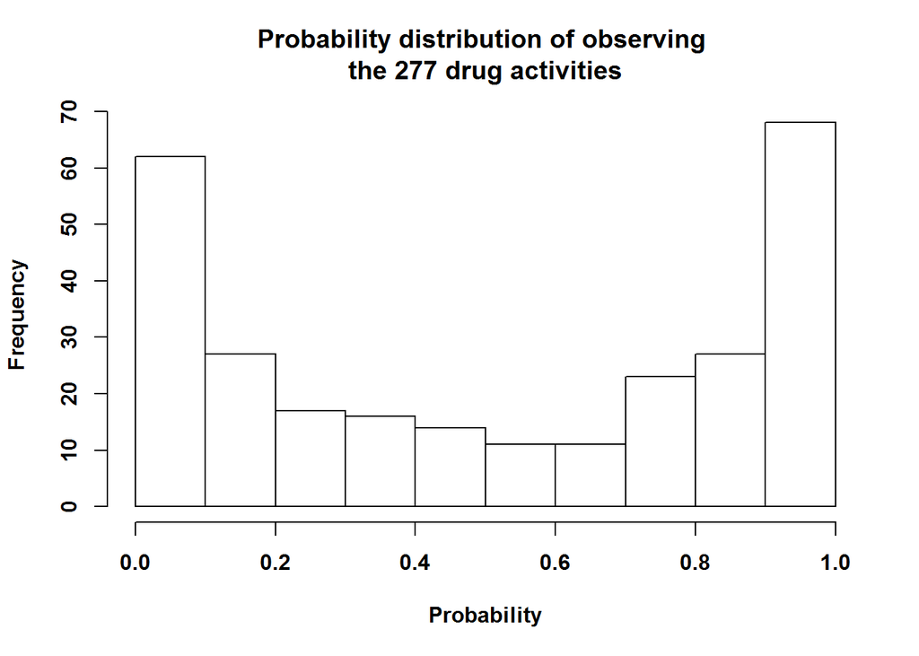

## 4 and 5. Selecting the significant compounds and computing expected p-value for additive effect

In this step, the p-values from the bimodal distribution shown earlier are converted to -log10 units. Only drugs that reach the cutoff, meaning drugs that show significant inversion of the drug viper signatures to the phenotype viper signature, are used. This is where the additive effect of drugs are estimated, based on multiplying the probabilities of each drug to each other. This yields a n x n matrix of drugs giving the expected p-value for additive effect.

```r
    if (cutoff<1) cutoff <- colSums(ds<cutoff)
    if (cutoff[1]>1) {
        if (length(cutoff)==1) cutoff <- rep(cutoff, 2)
        dsf <- lapply(1:2, function(i, ds, cutoff) {
            -log10(ds[order(ds[, i])[1:cutoff[i]], i])
        }, ds=ds, cutoff=cutoff)
        names(dsf) <- names(cutoff)
        dm <- sqrt(matrix(dsf[[1]]*rep(dsf[[2]], rep(length(dsf[[1]]), length(dsf[[2]]))), length(dsf[[1]]), length(dsf[[2]]), dimnames=list(names(dsf[[1]]), names(dsf[[2]]))))
    }
```

## 6. Similarity between drugs

This is similar to step 3 but now we are estimating the similarity of drugs in the context of treating the tumor.

```r
    ddtmp <- lapply(drugsig, function(drugsig, dm, nn, ws) {
        tmp <- viperSimilarity(cbind(filterColMatrix(drugsig, match(rownames(dm), colnames(drugsig))), filterColMatrix(drugsig, match(colnames(dm), colnames(drugsig)))), nn=nn, ws=ws, method="two.sided")
        cortest(scale(tmp)[1:nrow(dm), ][, (nrow(dm)+1):sum(dim(dm))], nrow(drugsig))$z
    }, dm=dm, nn=nn, ws=ws)
    ddtmp1 <- sapply(ddtmp, as.vector)
    ddtmp1 <- apply(ddtmp1, 1, function(x, ints) {
        weighted.mean(abs(x), 1/abs(x)^ints, na.rm=T)
    }, ints=ints)
    dd <- matrix(ddtmp1, nrow(ddtmp[[1]]), ncol(ddtmp[[1]]), dimnames=list(rownames(ddtmp[[1]]), colnames(ddtmp[[1]])))
    dd <- dd[!is.na(rownames(dd)), ][, !is.na(colnames(dd))]
    rm(ddtmp)
```

## 7. Defining all drug combinations

This step just computes all combinations of the drugs that significantly differ from the tumor signature.

```r
    cname <- NULL
    rn <- rownames(dd)[-1]
    for (i in colnames(dd)[1:(ncol(dd)-1)]) {
        cname <- rbind(cname, cbind(rn, rep(i, length(rn))))
        rn <- rn[-1]
    }
```

## 8. Computing the synergy score

This step computes the estimated drug combination synergy. We will go over the complementation method only.

```r
    complemental = {
        isig <- rowMeans(sapply(drugsig, function(drugsig, dm, score, phsig, nn, ws, similarity, dnes) {
            dsig <- filterColMatrix(drugsig, match(rownames(dm), colnames(drugsig)))
            d1 <- dsig[, rep(1:ncol(dsig), rep(ncol(dsig), ncol(dsig)))]
            d2 <- dsig[, rep(1:ncol(dsig), ncol(dsig))]
            d1sc <- t(t((abs(d1)/max(abs(d1)))^score) * dnes[match(colnames(d1), names(dnes))])
            d2sc <- t(t((abs(d2)/max(abs(d2)))^score) * dnes[match(colnames(d2), names(dnes))])
            isig <- (d1 * d1sc + d2 * d2sc)/(d1sc+d2sc)
            tmp <- viperSimilarity(cbind(phsig, -isig), nn=nn, ws=ws, method=similarity, symetric=symetric)
            return(cortest(scale(tmp)[, -1][1, ], nrow(isig))$z)
        }, dm=dm, score=score[1], phsig=phsig[, 1], nn=nn, ws=ws, similarity=similarity, dnes=(abs(dnes[, 1])/max(abs(dnes[, 1])))^score[2]))
        dnes1 <- dnes[match(rownames(dm), rownames(dnes)), 1]
        d1 <- dnes1[rep(1:length(dnes1), rep(length(dnes1), length(dnes1)))]
        d2 <- dnes1[rep(1:length(dnes1), length(dnes1))]
        dmax <- apply(cbind(d1, d2), 1, max)
        scs <- dsf[[1]][match(rownames(dm), names(dsf[[1]]))]
        scs <- cbind(scs[rep(1:length(scs), rep(length(scs), length(scs)))], scs[rep(1:length(scs), length(scs))])
        scs <- matrix(apply(scs, 1, max), length(dsf[[1]]), length(dsf[[1]]))/max(scs)
        syestim <- matrix((isig-dmax)*scs, nrow(dm), ncol(dm))
        if (length(which(syestim>0))>0) {
            syestim <- syestim*(syestim>0) + syestim/max(abs(syestim))*max(syestim)*(syestim<0)
        }
        colnames(syestim) <- rownames(syestim) <- rownames(dm)
    }
    diag(syestim) <- 0
    ortholist <- dd[lower.tri(dd)]
    sylist <- syestim[lower.tri(syestim)]
    names(sylist) <- names(ortholist) <- paste(cname[, 1], cname[, 2], sep=" x ")
    res <- list(phdrugs=sapply(dsf, function(x) x), actmatrix=dm, orthomatrix=dd, symatrix=syestim, orthodrugs=ortholist[order(ortholist, decreasing=T)], sydrugs=sylist[order(sylist, decreasing=T)], param=list(nn=nn, similarity=similarity, cutoff=cutoff, method=method, scc=scc))
    class(res) <- "phenotypeSynergy"
```

## Output

**Now you have your output. I’m showing only 2 elements from the 7 element list, but these data frames offer the necessary information.**

```
## Top drugs for patient
```

```
##                res.phdrugs...1.
## Palbociclib            3.878151
## Panobinostat           3.608129
## ONO-4059               2.947169
## Mercaptopurine         2.552252
## Decitabine             2.551292
## Eniluracil             2.507096
```

```
## Top synergistic drug combinations for the patient
```

```
##                             res.sydrugs
## Eniluracil x Mercaptopurine   0.8663326
## Cyclophosphamide x ONO-4059   0.7667767
## Panobinostat x Palbociclib    0.7522824
## Exemestane x Panobinostat     0.7353311
## Eniluracil x Decitabine       0.6866318
## Glasdegib x Pazopanib         0.6422243
```